# Seminar 1

Justas Mundeikis

2019-03-06

# 1 Reikiamų programų instaliavimas

Instaliuokite šias programas savo asmeniniame kompiuteryje..

- Instaliuokite R
- Instaliuokite RStudio
- Instaliuokite GitBash
- Instaliuokite Sublime
- Nepamirškite pagrindių Git nustatymų

```r
$ git config --global user.name "Vardas Pavardė"
$ git config --global user.email vardas.pavardė@evaf.vu.lt #arba kitas email, kurio registravotės @GitHub
$ git config --global core.pager cat
$ git config --global core.askPass ""
$ git config --global core.editor nano.exe
# here the absolute link to the execution file might be different on every computer!
$ git config --global core.editor /c/Users/USER/Download/sublime/sublime_text.exe
```

# 2 Paskyrų susikūrimas

Susikurkite savo paskyrą, naudodami bet kokį pseudonimą @Github, tačiau naudodami savo universitetinį email vardas.pavarde@stud.vu.lt. Tokiu atveju, jeigu nepavyktų aktyvuoti savo studentiško email, naudokite asmeninį email.

# 3 Nuosavo tinklapio sukūrimas

## 3.1 Seminaro darbo tikslas

Šio seminaro tikslas naudojantis *Git*, *Sublime* ir *Github* sukurti savo nuosavą internetinį puslapį. Pastaba: Tarkime, kad mano studento nr yra “S175”, Jūsų gali būti kitoks, tada naudojate savo studento nr vietoj mano “S175” Git komandose. Taip darome todėl, jog atliekant šias uždutis nuniversitete, nesimaišytų folderiai.

## 3.2 Žingsniai

Tinklapis bus kuriamas kiekvieno studento asmeniniame folderyje S1xxxxx, jame sukuriant subfolderį “webpage”.

```r
# atspirties taškas VU PC /c/Users/studentas, todėl
cd Desktop
mkdir -p S175/webpage
cd S175/webpage
```

Siekiant, jog Git pradėtų sekti veiklą folderyję, būtina pirma inicijuoti Git

```r
git init
```

Kiekvieno tinklapio bazinis dokumentas yra “index.html”, kurį galime susikurti CLI pagalba

```r
touch index.html
```

*Sublime* editorius pranašus tuo, jog pažįsta aibę skirtingų sintaksių. Koduojant šiuo atveju html, patartina nustatyti: View -> Syntax -> html Tada editoriuje įrašome

```r
Čia kuriamas mano tinklapis
```

išsaugome editoriaus pakeitimus su CTRL+S ir pabandome atidaryti sukurtą index.html failą (arba jeigu jau atidarytas, atnaujinant su F5), kurį atidaryti turėtų viena iš interneto naršyklių.

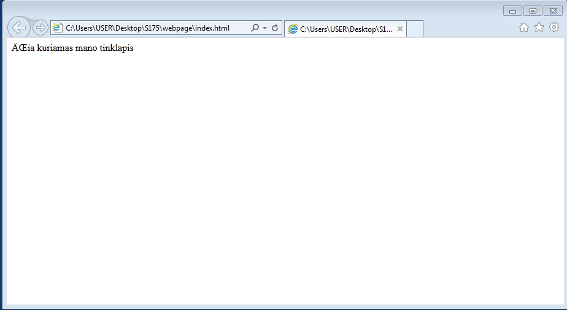

Tam kad dokumentas turėtų antraštę, į pirmą eilutę parašome: `<h1> S175 tinklapis <\h1>`

```r
<h1> S175 tinklapis <\h1>
Čia kuriamas mano tinklapis
```

Tiesa, *Sublime* yra pakankamai protingas ir pradėjus rašyti `<h` išmeta pasirinkimą, pasirinkus su TAB / pele `h1` pats supildo viską, bereikia įrašyti tik savo tekstą.

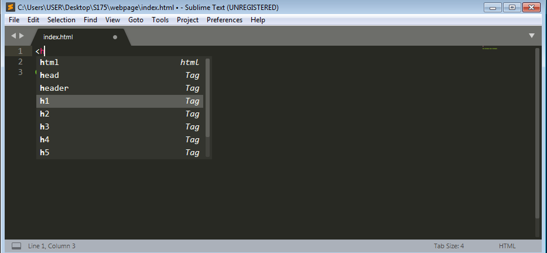

Išsaugokite pakeitimus editoriuje ir atnaujinkite naršyklę.

[figure not shown]

Pasiekėme stadiją, kai norime neprarasti įdirbio, todėl padarome folderio “nuotrauką” su Git

```r
git add .
git commit -m "Sukuriamas index.html failas"
```

Dabar prikurkime šiek tiek teksto mūsų tinklapiui pvz., “Šio tinklapio kūrimas yra 1.Seminaro darbas” ir išsaugome editoriaus pakeitimus

```r
<h1>S175 tinklapis</h1>

Čia kuriamas mano tinklapis

Šio tinklapio kūrimas yra  1.Seminaro darbas
```

Su komanda `git status` pasitikriname, ar Git seka mūsų dokumentą. Git output turėtų būti daugmaž toks:

```r
USER@PC MINGW64 ~/Desktop/s175/webpage (master)
$ git status
On branch master
Changes not staged for commit:
  (use "git add <file>..." to update what will be committed)
  (use "git checkout -- <file>..." to discard changes in working directory)

        modified:   index.html
```

Taigi turime modifikuotą dokumentą, kurio pakeitimai dar nėra staged. Su komanda `git diff` galime pasitiktinti, o kokius skirtumus Git atpažįsta

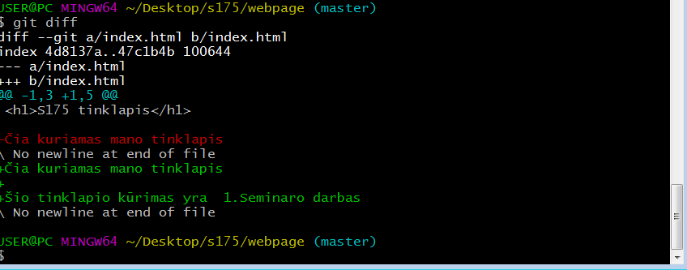

Kadangi pakeitimai teisingi, galima `git commit -am "Sukurta index.html antraštė"`. Kadangi jau trackinam visus failus tai galima naudoti sutrumpintą komandą, kur `-am` reiškia `-all` ir `-m`

Na bet į internetinį puslapį toli gražu tai dar nepanašu… Todėl į editorių perrašome šį bloką (arba pradedame typinti `<h` ir pasirenkame html ir užpildome trūkstama informacija

```r
<!DOCTYPE html>
<html>
<head>
    <title></title>
</head>
<body>
<h1>S175 Tinklapis</h1>
<p>Čia kuriamas mano tinklapis</p>
<p>Šio tinklapio kūrimas yra 1.Seminaro darbas </p>
</body>
</html>
```

| html kodas | kodo reikšmė |
| --- | --- |
| `<!DOCTYPE html>` | nusako koks tai dokumento tipas, šiuo atveju tai html dokumentas |
| `<html>` | atidaro html tag |
| `<head>` | atidaro head tag |
| `` <title>``</title> `` | atidaro ir uždaro title tag |
| `</head>` | uždaro head tag |
| `<body>` | atidaro body tag (t.y. puslapio turinys) |
| `<h1></h1>` | atidaro ir uždaro antraštės tipo tag |
| `<p></p>` | atidaro ir uždaro paragrafo tag |
| `</body>` | uždaro body tag |
| `</html>` | uždaro html tag |

[figure not shown]

Jeigu norime, kad pats puslapis, turėtų naršyklei suprantamą pavadinimą, pvz., “Home” papildome kodą:

```r
<!DOCTYPE html>
<html>
<head>
    <title>Home</title>
</head>
<body>
<h1>S175 Tinklapis</h1>
<p>Čia kuriamas mano tinklapis</p>
<p>Šio tinklapio kūrimas yra 1.Seminaro darbas </p>
</body>
</html>
```

Dar vienas nemalonus dalykas, naršyklė nesupranta lietuviškų simbolių, todėl įterpiame po pirmos eilutės: `<meta charset="utf-8"/>`, taigi priskiriame meta informaciją puslapiui ir pasakome, jog naršyklė skaitydama šį tekstą naudotų `utf-8` kodavimą, kuris turi ir lietuviškus simbolius

```r
<!DOCTYPE html>
<meta charset="utf-8"/>
<html>
<head>
    <title>Home</title>
</head>
<body>
<h1>S175 Tinklapis</h1>
<p>Čia kuriamas mano tinklapis</p>
<p>Šio tinklapio kūrimas yra 1.Seminaro darbas </p>
</body>
</html>
```

Dabartinis tinklapis jau daug maž panašus į tinklapį.

[figure not shown]

Išsaugome editoriaus pakeitimus ir commitinam pakeitimus `git commit -am "papildytas index.html"`.

Asmeninėje *Github* paskyroje sukuriame naują repo pavadinimu “webpage”. Praleidžiame aprašymą ir paliekame *be README* . Kodėl nesukuriame README.md? Nes lokali repo jau turi savo “istoriją” ir jeigu sukūrę nuotolinę repo inicijuosime ją su README.md, tada ir nuotolinė repo turės savo, bet jau kitokią istorija. O tai reikš, jog siunčiant lokalią repo į nuotolinę, kils konfliktas dėl skirtingų Git istorijų.

```r
# susikūrus repo webpage, Github parodys instrukciją, kaip susieti lokalią ir nuotolinę repo
# arba atitinkamai:
git remote add origin https://github.com/vartotojovardas/webpage.git

# susiejus su Github (pasitikrinti galima visada su "git remote -v")
git push -u origin master

# -u reiškia, jog vietinė repo išmoksta, kad Githube susieta repo yra upstream repository, o tai leis ateityje tiesiog parsisiųsti naudojant  komandą "git pull"
```

Ataujiname Github tinklapį ir pamatysim

[figure not shown]

Kadangi nėra blogai turėti README failą, tai Git Bash sukuriame ji.

```r
touch README.md
```

Atsidarome failą su *Sublime* ir perrašome šį Markdown formatuotą tekstą:

`# Bandomasis puslapis` `Čia kuriamas bandomasis puslapis. Ši paskyra priklauso studentui S....` `Šis puslapis kurimas Vilniaus Universiteto Ekonomikos ir verslo administravimo fakultete vykstančios **"Duomenų analizės įvado"** paskaitų metu.` [Čia galima rasti daugiau Markdown formatavimo subtilybių: [Markdown cheetsheat](https://guides.github.com/pdfs/markdown-cheatsheet-online.pdf) ]

```r
git add .
git commit -m "Sukurtas README.md failas"
git push origin master
```

Atnaujinius GitHub puslapį, matome:

[figure not shown]

Puslapis dabar atrodo gana nykiai, todėl pabandysime pridėti porą linksmų paveiksliukų. Siekiant, jog folderyje “webpage” būtų bent kiek tvarkos, paveiksliukus dėsime atskirame subfolderyje “images”

```r
mkdir images
```

GitBash stiprus, nes gali netgi atsiųsti failus iš interneto:

```r
curl -o images/github.png -OL https://upload.wikimedia.org/wikipedia/commons/thumb/b/b3/GitHub.svg/567px-GitHub.svg.png
```

Folderyje images turėjo atsirasti šis paveiksliukas

[figure not shown]

Dabar reikia dar šį paveiksliuką įterpti į index.html failą. Tai galime padaryti html body įrašę tokią eilutę: `<img src="path/to/file" alt="Description">`. Kadangi paveiksliukas yra images folderyje tai įrašome atitinkamai `src=""` (source). Na bet kad būtų linksmiau, pridedame dar ir vieną paveikklsiuk iš interneto. Visas kodas dabar turėtų atrodyti taip. Alternatyviai galite įklijuoti kitus paveiksliukus.

```r
<!DOCTYPE html>
<meta charset="utf-8"/>
<html>
<head>
    <title>Home</title>
</head>
<body>
<h1>S175 Tinklapis</h1>
<p>Čia kuriamas mano tinklapis</p>
<p>Šio tinklapio kūrimas yra 1.Seminaro darbas </p>
<p><img src="images/github.png" alt="github paveiksliukas"></p>
<p><img src="https://studyguide.itu.dk/~/media/studyguide/student-life/facilities-at-itu/it-facilities/github/github_logo.png?h=248&w=573&la=en">
</p>
</body>
</html>
```

Belieka:

```r
git add . && git commit -m "pridėti paveiksliukai"
git push
```

Ataujinus Github puslapį, matome, jog atsirado folderis “images”

[figure not shown]

## 3.3 Naujos atšakos sukūrimas (paralelinis darbas) ir about.html sukūrimas

GitBash sukuriame naują atšaką ir einame į ją

```r
git checkout -b about-puslapis
# tolygu
git banch about-puslapis
git chekcout about-puslapis
```

Pasidarome index.html kopiją naudodamiesi CLI komanda `cp`

```r
cp index.html about.html
```

Atsidarome about.html su Sublime ir pakeičiame turinį, supildant savo duomenis

```r
<!DOCTYPE html>
<meta charset="utf-8"/>
<html>
<head>
    <title>About</title>
</head>
<body>
<p><strong>Vardas:</strong> Vardas Pavardė</p>
<p><strong>Stud. nr.:</strong> S175</p>
<p><strong>Kursas</strong>: Ekonomika</p>
<p><strong>Grupė:</strong> xx</p>
</body>
</html>
```

Kadangi norime, jog ir pagrindiniame puslapyje (Home) būtų nuorodą į puslapi apie mus (About), turime pakeisti index.html. Įterpiame `<a href="about.html">Daugiau informacijos apie mane</a>`, tagas `<a>` reiškia “anchor” arba “inkaras” ir yra naudojamas nuorodoms.

```r
<!DOCTYPE html>
<meta charset="utf-8"/>
<html>
<head>
    <title>Home</title>
</head>
<body>
<h1>S175 Tinklapis</h1>
<p>Čia kuriamas mano tinklapis</p>
<p>Šio tinklapio kūrimas yra 1.Seminaro darbas </p>
<br>
<a href="about.html">Daugiau informacijos apie mane</a>
<p><img src="images/github.png" alt="github paveiksliukas"></p>
<p><img src="https://studyguide.itu.dk/~/media/studyguide/student-life/facilities-at-itu/it-facilities/github/github_logo.png?h=248&w=573&la=en">
</p>
</body>
</html>
```

```r
git add . && git commit -m "sukurtas about.html puslapis
```

Tačiau esame atšakoje “about-puslpis”, todėl grįžtame į “master”. Jame suprantama nėra pakeitimų, kurios padarėme atšakoje, todėl nusprendžiame sujungti atšaką su master. Jeigu nėra kokių nors jungimo klaidų, kurias reiktų pataisyti ranka, nuostabu! Jeigu nebereikia about-puslapis atšakos, kuri yra sujungta (merge), galime ją ištrinti

```r
git checkout master # grįžta į master
git merge about-puslapis # inkorporuoja aboutžpuslapis esančius pakeitimus į master
git branch -d about-puslapis # ištrina about-puslapis atšaką

#ar ištrynėme sėkmingai, galima pasitikrinti su
git branch -v
```

Po sujungimo staginti ir commitinti nebereikia, nes staginimas ir commitinimas įvyko dar about-puslapis atšakoje!

```r
git push
```

## 3.4 Tinklapio paleidimas online:

Github paskyroje, webpage repo reikia eiti į “Settings”

[figure not shown]

Ties “GitHub Pages” iš “None” pasikeisti į “master branch”

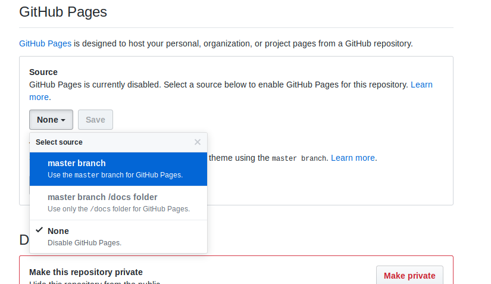

Paspaudus nuorodą:

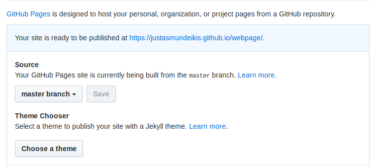

Atsidaro pilnai veikiantis tinklapis! Sveikinu!

[figure not shown]

Jeigu norite sukurti labiau sofistikuotą puslapį, galima naudotis html editoriaus pagalba, pvz., https://html-online.com/editor/

## 3.5 Tinklapio url į google sheets

Tam kad galėčiau įvertinti Jūsų darbą, šio tinklapio, ar kad ir kokį susikūrėte kitą, url nukopijuokite į VMA pateiktą *Google Seehts*